# Linear Regression

- Regression analysis helps us to understand how much the dependent variable changes with a change in one or more independent variables
- Forecast or impact of chages. Identify the strength of the effect that the independent variable(s) have on a dependent variable.
- Predict trends and future values.

### Simple Linear Regression

Equation of line:

$y = w_1x_1 + w_2$

where,  
slope: $w_1$  
y-intercept: $w_2$

#### Error Functions

The two most common error functions for linear regression are:

- Mean Absolute Error (MAE)
- Mean Squared Error (MSE)

##### Mean Absolute Error:

- The vertical distance from the point to the line is the $y - \hat{y}.$

Mean Absolute Error is the sum of all the absolute errors divided by the number of points:

$Error = \frac{1}{m} \sum_{i=1}^{m} |y - \hat{y}|$

Using gradient descent we get the best possible fit line with the smallest possible MAE.

##### Mean Squared Error:

Mean Squared Error is the sum of all the squared errors divided by the number of points:

$Error = \frac{1}{2m} \sum_{i=1}^{m} (y - \hat{y})^2$

By minimizing the average sum of squared errors, MSE is minimized and we get the best possible fit line.

#### Mean Squared Error

**Data:**  
$x_1, x_2, ...., x_m$

**Labels:**  
$y_1, y_2, ...., y_m$

**Predictions:**  
$\hat{y_i} = w_1x_i + w2$

where,  
*slope:* $w_1$  
*y_intercept:* $w_2$

**Mean Squared Error:**

Given the values of $w_1$ and $w_2$, we can calculate the predictions and the error based on these values of $w_1$ and $w_2$.

$Error(w_1, w_2) = \frac{1}{2m} \sum_{i=1}^{m} (\hat{y} - y)^2 $

In order to minimize this error, we need to take the derivatives wrt the input variables $w_1$ and $w_2$ and set them both equal to zero. We calculate the derivites and we get these two formulas:

$0 = \frac{\sum{x_i}^2}{m}w_1 + \frac{\sum{x_i}}{m}w_2 + \frac{\sum{x_iy_i}}{m} $

$0 = \frac{\sum{x_i}}{m}w_1 + w_2 + \frac{\sum{y_i}}{m} $

Now, we need to solve for $w_1$ and $w_2$ for these 2 equations to be zero. We have a system of two equations and two unknowns to be solved.

For a system with greater number of dimensions in inputs, the problem would have *n* equations with *n* unknowns which will need a lot of computational power depending on the size of *n*.

Therefore, gradient decent method is used to obtain a solution that fits our data very well.

#### 2-Dimensional solution

**Data:**  
$x_1, x_2, ...., x_m$

**Labels:**  
$y_1, y_2, ...., y_m$

**Predictions:**  
$\hat{y_i} = w_1x_i + w_2$

where,  
*slope:* $w_1$  
*y_intercept:* $w_2$

**Mean Squared Error:**

Given the values of $w_1$ and $w_2$, we can calculate the predictions and the error based on these values of $w_1$ and $w_2$.

$E(w_1, w_2) = \frac{1}{2m} \sum_{i=1}^{m} (\hat{y} - y)^2 $

We need to minimize this error function. Ignoring $\frac{1}{m}$, and replacing the value of $\hat{y_i} = w_1x_i + w_2$, we get:

$E(w_1, w_2) = \sum_{i=1}^{m} (\hat{y} - y)^2 = \sum_{i=1}^{m} (w_1x_i + w_2 - y)^2 $

In order to minimize this error function, we need to take the derivatives wrt $w_1$ and $w_2$ and set them equal to 0.

Using the chain rule, we get:

$\frac{\partial E}{\partial w_1} = \sum_{i=1}^{m} (w_1x_i + w_2 - y_i)x_i = w_1 \sum_{i=1}^{m} {x_i}^2 + w_2 \sum_{i=1}^{m} x_i - \sum_{i=1}^{m} x_iy_i $

and

$\frac{\partial E}{\partial w_2} = \sum_{i=1}^{m} (w_1x_i + w_2 - y_i) = w_1 \sum_{i=1}^{m} x_i + w_2 \sum_{i=1}^{m} 1 - \sum_{i=1}^{m} y_i $

Setting the two equations to zero gives us the following two equations and two variables (where the variables are $w_1$ and $w_2$)

$0 = w_1 \sum_{i=1}^{m} {x_i}^2 + w_2 \sum_{i=1}^{m} x_i - \sum_{i=1}^{m} x_iy_i $

$0 = w_1 \sum_{i=1}^{m} x_i + w_2 \sum_{i=1}^{m} 1 - \sum_{i=1}^{m} y_i $

then

$ w_1(\sum_{i=1}^{m} {x_i}^2) + w_2(\sum_{i=1}^{m} x_i) = \sum_{i=1}^{m} x_iy_i $

$ w_1(\sum_{i=1}^{m} x_i) + w_2(m) = \sum_{i=1}^{m} y_i $

We can solve the 2 equations and 2 variables by multiplying the first equation by $ w_1(\sum_{i=1}^{m} x_i) $ and the second equation by *m* and subtract them to obtain a value for $w_1$, and then replace this value in the first equation, we get the following:

$ w_1 = \frac{m(\sum_{i=1}^{m} x_iy_i) - (\sum_{i=1}^{m} x_i)(\sum_{i=1}^{m} y_i)}{m(\sum_{i=1}^{m} {x_i}^2) - (\sum_{i=1}^{m} x_i)^2}$

$ w_2 = \frac{(\sum_{i=1}^{m} x_iy_i)(\sum_{i=1}^{m} x_i) - (\sum_{i=1}^{m} {x_i}^2)(\sum_{i=1}^{m} y_i)}{m(\sum_{i=1}^{m} x_i)^2 - m(\sum_{i=1}^{m} {x_i}^2)}$

These are the values for the model coefficients $w_1$ and $w_2$.

### Multiple linear regression

The model equation with *n* predictor variables:

$y = x_0 + w_1x_1 + w_2x_2 + ... + w_{n}x_{n}$

- $y$ is the response
- $w_1$ is the coefficient for $x_1$ (the first feature)
- $w_n$ is the coefficient for $x_n$ (the *n*th feature)

In this case:

The $w$ values are called the **model coefficients**

- These values are "learned" during the model fitting step using the "least squares" criterion
- Then, the fitted model can be used to make predictions

#### Multiple Linear Regression assumptions

- Residuals have a mean of zero
- Non heteroscedastic (residuals must have constant variance)
- Normality of errors
- Normality of independent variables
- Residuals are not autocorrelated
- Need linear relationships
- Need more observations (rows) than variables (columns)
- No excessive multicollinearity

#### n-Dimensional solution

Instead of 2 dimensions as discussed above, if the data has *n* dimensions, the procedure involves matrix operations. The matrix X contains data where each row is one of the data points, and ${x_0}^{(i)} = 1$ represents bias.

[figure not shown]

Let *y* be the matrix containing labels.

[figure not shown]

Let *W* be the matrix containing weights.

[figure not shown]

And so the equation for the **Mean Squared Error** can be written as the following matrix product:

$E(W) = \frac{1}{2m} \sum_{i=1}^{m} (y - \hat{y})^2$

If $e(w) = (y-\hat{y})$ and $\hat{y} = XW $, in terms of multiplication, $e^2$ can be written as $e^{T}e$

$E(W) = \frac{1}{2m} (y - XW){^T}(y-XW) $

$E(W) = \frac{1}{2m}((XW)^T - y^T)(XW -y) $

Again, since we need to minimize it, we can forget about the factor of $\frac{1}{2m}$, so expanding, we get

$E(W) = W^{T}X^{T}XW - (XW)^{T}y - y^{T}(XW) + y^{T}y.$

Notice that in the sum, the second and the third terms are the same, since it's the inner product of two vectors, which means it's the sum of the products of its coordinates. Therefore,

$ E(W) = W^{T}X^{T}XW - 2(XW)^{T}y + y^{T}y.$

Now, to minimize this, we need to take the derivative with respect to all values in the matrix *W*. Using the chain rule, as we used above, we get the following:

$ \frac{\partial E}{\partial W} = 2X^{T}XW - 2X^{T}y = 0 $

And in order to set this equal to zero, we need

$X^{T}XW - X^{T}y = 0 $, or equivalently,

$W = (X^{T}X)^{-1}X^{T}y$

This are the required weights.

This method is computationally intensive, since finding the inverse of the matrix $X^{T}X$ is hard, if the value of *n* is large. Alternatively, gradient descent is repeated many times.

# Gradient Descent

The objective is to minimize the error between the point and estimated line.

[figure not shown]

**Error function:**

$w_i \to w_i - \alpha \frac{\partial }{\partial w_i} Error $

- The plot of the error function is a parabola with weights on x-axis and Error on the y-axis.
- Way to descend from large error is to take the derivative or gradient of the Error function wrt the weights $w_i$.
- The gradient points to the direction where the function increases the most. Therefore, the negative of this gradient is going to point down to the direction where the function decreases the most.
- The error descends in the direction of the negative gradient. This means we change the weights $w_i$ to $w_i - \alpha \frac{\partial }{\partial w_i} Error $.
- By multiplying the derivative of the Error term wrt the weights with learning rate $(\alpha)$ the step-size is small.
- This means that the error function is decreasing and we're closer to the minimum.
- By doing this many times, the result is either a minimum or a pretty good value where the error is small which signifies a pretty good solution to the linear regression problem.

#### Mini Gradient Descent

- The MAE/MSE minimization is applied to data points all at the same time and the process is repeated many times

[figure not shown]

#### Stochastic Gradient Descent

- The MAE/MSE minimization is applied to data points one by one and the process is repeated many times

[figure not shown]

#### Mini-Batch Gradient Descent

- The MAE/MSE minimization is applied to data points into many small batches and the process is repeated many times.
- Each batch will have roughly the same number of points and each batch is used to update the weights.

[figure not shown]

### Linear Regression Assumptions

- Works best when the data is linear
- Sensitive to outliers

### Polynomial Regression

Higher order polynomial equations to fit data following a non-linear trend.

$ \hat{y} = w_1x^3 + w_2x^2 + w_3x + w_4 $

### Complexity of model

Simpler models have a tendency to generalize better than complex models. To make complexity of model into account while measuring the error, regularization techniques are used.

Total error = Error from misclassification + complexity

#### L1 Regularization

- Takes the coefficients of the model and adds the absolute values to the error.
- Computationally inefficient, unless the data is sparse
- Feature selection

#### L2 Regularization

- Takes the sum of squares of coefficients of the model and adds the value to the error.
- Computationally efficient (computing derivatives of squares is efficient), good for non-sparse data

## Examples

```python
# Add import statements
import pandas as pd
from sklearn.linear_model import LinearRegression

# Assign the dataframe to this variable.
# TODO: Load the data
bmi_life_data = pd.read_csv('bmi_and_life_expectancy.csv')
print(bmi_life_data.head())

# Make and fit the linear regression model
#TODO: Fit the model and Assign it to bmi_life_model
bmi_life_model = LinearRegression()
bmi_life_model.fit(bmi_life_data[['BMI']], bmi_life_data[['Life expectancy']])

# Make a prediction using the model
# TODO: Predict life expectancy for a BMI value of 21.07931
laos_life_exp = bmi_life_model.predict([[21.07931]])
print("Life expenctancy: {}".format(laos_life_exp))
```

```
       Country  Life expectancy       BMI
0  Afghanistan             52.8  20.62058
1      Albania             76.8  26.44657
2      Algeria             75.5  24.59620
3      Andorra             84.6  27.63048
4       Angola             56.7  22.25083
Life expenctancy: [[60.31564716]]
```

```python
from sklearn.linear_model import LinearRegression
from sklearn.datasets import load_boston

# Load the data from the boston house-prices dataset
boston_data = load_boston()
x = boston_data['data']
y = boston_data['target']
print('X values:\n {}'.format(x[:1]))
print()
print('Y values:\n {}'.format(y[:1]))
print()

# Make and fit the linear regression model
lr_model = LinearRegression()
lr_model.fit(x,y)

# Make a prediction using the model
sample_house = [[2.29690000e-01, 0.00000000e+00, 1.05900000e+01, 0.00000000e+00, 4.89000000e-01,
                6.32600000e+00, 5.25000000e+01, 4.35490000e+00, 4.00000000e+00, 2.77000000e+02,
                1.86000000e+01, 3.94870000e+02, 1.09700000e+01]]

# Predict housing price for the sample_house
prediction = lr_model.predict(sample_house)
print('Prediction:\n {}'.format(prediction))
```

```
X values:
 [[6.320e-03 1.800e+01 2.310e+00 0.000e+00 5.380e-01 6.575e+00 6.520e+01
  4.090e+00 1.000e+00 2.960e+02 1.530e+01 3.969e+02 4.980e+00]]

Y values:
 [24.]

Prediction:
 [23.68284712]
```

```python
from sklearn.model_selection import KFold
from sklearn.linear_model import LinearRegression, Lasso, Ridge, ElasticNet, SGDRegressor
import numpy as np
import pylab as pl
```

```python
from sklearn.datasets import load_boston
boston = load_boston()

# In order to do multiple regression we need to add a column of 1s for x0
x = np.array([np.concatenate((v,[1])) for v in boston.data])
y = boston.target

np.set_printoptions(precision=2, linewidth=120, suppress=True, edgeitems=4)
```

```python
# Create linear regression object
linreg = LinearRegression()

# Train the model using the training sets
linreg.fit(x,y)
```

```
LinearRegression(copy_X=True, fit_intercept=True, n_jobs=None,
         normalize=False)
```

```python
# Let's see predictions for the first 10 instances
print(linreg.predict(x[:10]))
```

```
[30.   25.03 30.57 28.61 27.94 25.26 23.   19.54 11.52 18.92]
```

```python
# Compute RMSE on training data
# p = np.array([linreg.predict(xi) for xi in x])
p = linreg.predict(x)
# Now we can constuct a vector of errors
err = abs(p-y)

# Let's see the error on the first 10 predictions
print(err[:10])
```

```
[6.   3.43 4.13 4.79 8.26 3.44 0.1  7.56 4.98 0.02]
```

```python
# Dot product of error vector with itself gives us the sum of squared errors
total_error = np.dot(err,err)
# Compute RMSE
rmse_train = np.sqrt(total_error/len(p))
print(rmse_train)
```

```
4.679191295697281
```

```python
# We can view the regression coefficients
print('Regression Coefficients: \n', linreg.coef_)
```

```
Regression Coefficients:
 [ -0.11   0.05   0.02   2.69 -17.77   3.81   0.    -1.48   0.31  -0.01  -0.95   0.01  -0.52   0.  ]
```

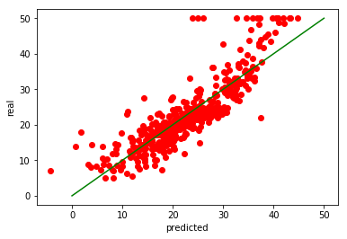

```python
# Plot outputs
%matplotlib inline
pl.plot(p, y,'ro')
pl.plot([0,50],[0,50], 'g-')
pl.xlabel('predicted')
pl.ylabel('real')
pl.show()
```

#### Ridge Regression

```python
# Create linear regression object with a ridge coefficient 0.5
ridge = Ridge(fit_intercept=True, alpha=0.5)

# Train the model using the training set
ridge.fit(x,y)
```

```
Ridge(alpha=0.5, copy_X=True, fit_intercept=True, max_iter=None,
   normalize=False, random_state=None, solver='auto', tol=0.001)
```

```python
# Compute RMSE on training data
# p = np.array([ridge.predict(xi) for xi in x])
p = ridge.predict(x)
err = p-y
total_error = np.dot(err,err)
rmse_train = np.sqrt(total_error/len(p))

method_name = 'Ridge Regression'
print('Method: %s' %method_name)
print('RMSE on training: %.4f' %rmse_train)
```

```
Method: Ridge Regression
RMSE on training: 4.6854
```

#### Regression using Stochastic Gradeint Descent

```python
# SGD is very senstitive to varying-sized feature values. So, first we need to do feature scaling.

from sklearn.preprocessing import StandardScaler

scaler = StandardScaler()
scaler.fit(x)
x_s = scaler.transform(x)

sgdreg = SGDRegressor(penalty='l2', alpha=0.15, max_iter=200)

# Compute RMSE on training data
sgdreg.fit(x_s,y)
p = sgdreg.predict(x_s)
err = p-y
total_error = np.dot(err,err)
rmse_train = np.sqrt(total_error/len(p))

method_name = 'Stochastic Gradient Descent Regression'
print('Method: %s' %method_name)
print('RMSE on training: %.4f' %rmse_train)
```

```
Method: Stochastic Gradient Descent Regression
RMSE on training: 4.8071
```